# Studying eviction-related variables and their relevance with COVID19 statistics

## Fundamental Calculations

Most names of the columns stay the same (c.f. covid.eviction2 dataset)

```r
Us.covid.rate <- covid.eviction2 %>%
  summarize(US_covid_cases_rate = sum(covidCases)/329584132,
            US_covid_death_rate = sum(covidDeaths)/sum(covidCases))

covid.eviction2.clust <- covid.eviction2.clust %>%
  mutate(US_covid_cases_rate = Us.covid.rate$US_covid_cases_rate,
         US_covid_death_rate = Us.covid.rate$US_covid_death_rate)

State.covid.rate <- covid.eviction2.clust %>%
  group_by(State) %>%
  summarize(state_covid_cases_rate = covidCases/population,
            state_covid_death_rate = covidDeaths/covidCases)

covid.eviction2.clust <- full_join(covid.eviction2.clust, State.covid.rate,
                                  by = "State")

covid.eviction2.clust <- covid.eviction2.clust %>%
  mutate(covidCases_greater_US = ifelse(state_covid_cases_rate > US_covid_cases_rate,
                                           1,
                                           0)) %>%
  mutate(covidDeaths_greater_US = ifelse(state_covid_death_rate >
                                          US_covid_death_rate,
                                         1,
                                         0))
```

## State Covid CASE Rates:

### lower than the US level

```r
c.lower.state <- covid.eviction2.clust %>%
  filter(covidCases_greater_US == 0)

c.lower.state.subset <- c.lower.state[,-c(18, 22:27)]

c.lower.state.scaled <- scale(c.lower.state.subset %>%
                              dplyr::select(-State))
c.lower.state.dist <- dist(c.lower.state.scaled)

c.low.case.hc.single = hclust(c.lower.state.dist, method = "single")
c.low.case.hc.avg = hclust(c.lower.state.dist, method = "average")
c.low.case.hc.complete = hclust(c.lower.state.dist, method = "complete")

c.low.case.hc.complete
```

```
##
## Call:
## hclust(d = c.lower.state.dist, method = "complete")
##
## Cluster method   : complete
## Distance         : euclidean
## Number of objects: 39
```

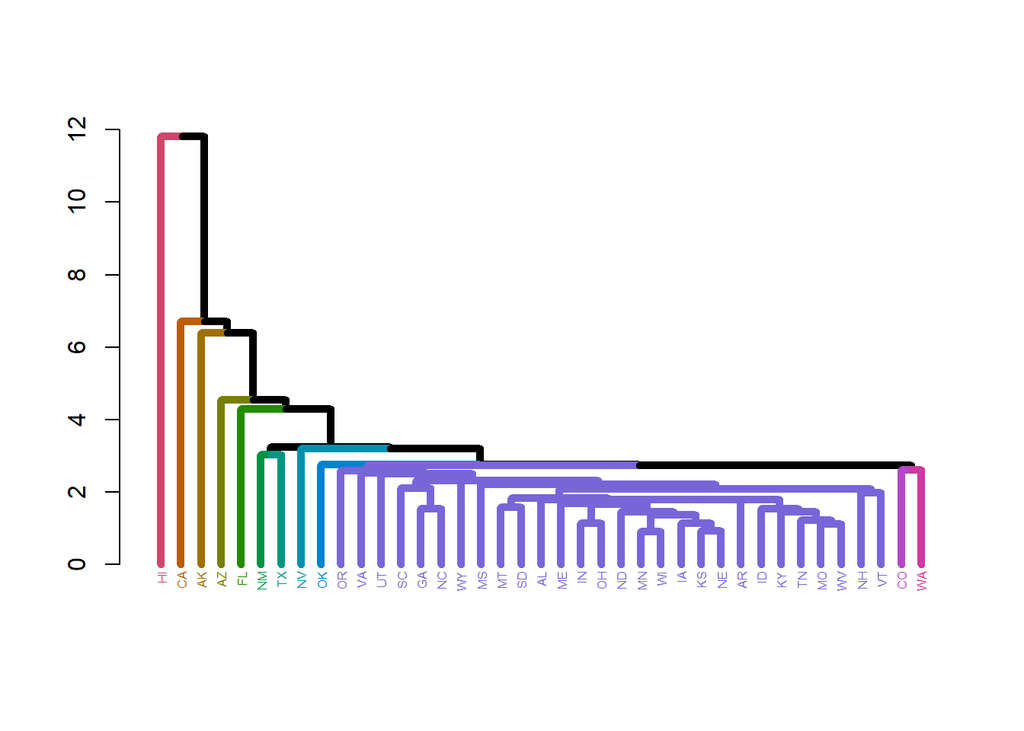

```r
c.low.case.hc.single %>%
  as.dendrogram() %>%
  place_labels(c.lower.state$State) %>%
  set("labels_cex", 0.5) %>%
  color_labels(k = 12) %>%
  set("branches_lwd", 5) %>%
  color_branches(k =12) %>%
  plot()
```

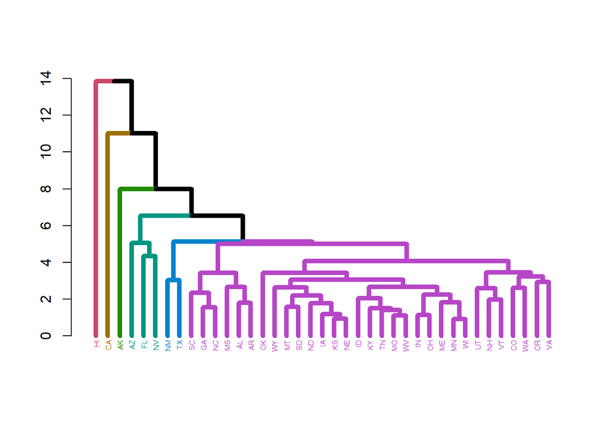

```r
c.low.case.hc.avg %>%
  as.dendrogram() %>%
  place_labels(c.lower.state$State) %>%
  set("labels_cex", 0.5) %>%
  color_labels(k = 6) %>%
  set("branches_lwd", 5) %>%
  color_branches(k =6) %>%
  plot()
```

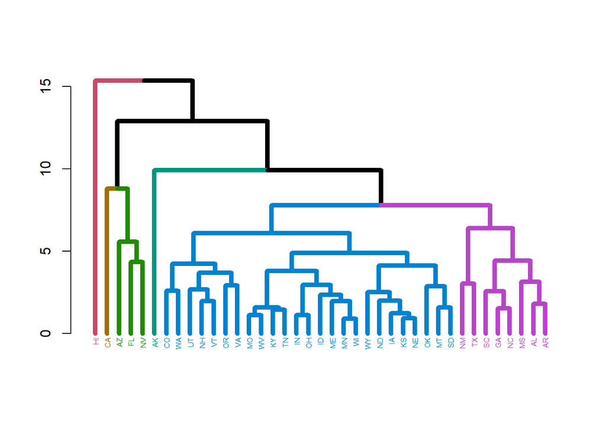

```r
c.low.case.hc.complete %>%
  as.dendrogram() %>%
  place_labels(c.lower.state$State) %>%
  set("labels_cex", 0.5) %>%
  color_labels(k = 6) %>%
  set("branches_lwd", 5) %>%
  color_branches(k =6) %>%
  plot()
```

Before going further into the usage of different linkage methods, one thing to observe from all three graphs is that there are many states. More specifically, this suggests that there are many states given the condition that the respective rate of covid cases is lower than the mean rate of covid cases across the nation, which may be reassuring.

#### Usage of linkage techniques

Euclidean distance is used as a metric for the distance of dissimilarities.

[Analysis of the Complete Linkage] Similarly to HI, CA and AK are not found to be similar to other states until much later, more specifically, at the height of around 10. Furthermore, it is interesting to observe that states are linked based on their physical proximities (e.g. NM and TX in purple), this does not hold true to all linkages (e.g. FL and NV in green). Let’s look further into these two examples.

##### NM & TX

```r
c.lower.state.subset %>%
  filter(State == "NM" | State == "TX" | State == "SC" | State == "SD")
```

```
## # A tibble: 4 x 20
##   State `poverty-rate` `renter-occupie~ `pct-renter-occ~ `median-gross-r~
##   <chr>          <dbl>            <dbl>            <dbl>            <dbl>
## 1 NM              15.6            8348              27.4             678.
## 2 SC              16.3           13619.             29.0             690.
## 3 SD              11.0            1730.             29.1             556.
## 4 TX              13.1           14899.             28.4             699.
## # ... with 15 more variables: `median-household-income` <dbl>,
## #   `median-property-value` <dbl>, `rent-burden` <dbl>, `pct-white` <dbl>,
## #   `pct-af-am` <dbl>, `pct-hispanic` <dbl>, `pct-am-ind` <dbl>,
## #   `pct-asian` <dbl>, `pct-nh-pi` <dbl>, `pct-multiple` <dbl>,
## #   `pct-other` <dbl>, `eviction-filings` <dbl>, covidCases <dbl>,
## #   covidDeaths <dbl>, population <dbl>
```

We compare NM and TX with SC (in the same color) and SD (grouped into another subset until their subsets merge at the height of around 7). From the data set, we can assume that some of the variables that were considered to match the two states NM and TX might have been as follows: poverty rate, eviction filings, percentage of hispanics, covidDeaths, and covidCases. Of course, because we’re loooking at a datset of just four states and do not compare all states from one another, this should be handled merely as a sample that allows us to see what variables *could have* been considered in the dendrogram and scatterplot. If this observation, however, can be generalized into the whole dataset that we used for the this hierarchical clustering, such an analysis allows us to assume that the influence of geographical proximity on clustering. That is, variables like poverty rate and percentage of hispanics may be similar to states that are located closely to each other due to socieconomic factors.